# Code_analysis

Yiming Qian

2021-01-25 14:10:38

# Purpose

This document shows the analysis following the preregistered plan.

# Analysis

## Imports

Importing and analyzing the data, where we have excluded the runs where accuracy is lower than the guess rate (50%) and there are zero scores in the surveys.

```r
data_fn <- file.path(file.path(params$data_path, params$csv_fn))
if (!file.exists(data_fn)) {
  stop('Data file cannot be found: `', data_fn, '`.')
}

# load the data and make each variable right
df1 <- readr::read_csv(data_fn)
df1_m <- df1 %>%
  filter(Sex == "Males")
df1_f <- df1 %>%
  filter(Sex == "Females")
```

## Check distributions

Preleminary test to check the test assumptions 1. Is the covariation linear? Form the plot below, check whether the relationship is linear. In the situation where the scatter plots show curved patterns, we are dealing with nonlinear association between the two variables.

2. Are the data from each of the 2 variables (x, y) follow a normal distribution? Use Shapiro-Wilk normality test –> R function: shapiro.test() and look at the normality plot —> R function: ggpubr::ggqqplot()
- Shapiro-Wilk test can be performed as follow: Null hypothesis: the data are normally distributed Alternative hypothesis: the data are not normally distributed

### Males

```r
# Shapiro-Wilk normality test
shapiro.test(df1_m$Motion_duration_Threshold) # => p <0.001
```

```
##
##  Shapiro-Wilk normality test
##
## data:  df1_m$Motion_duration_Threshold
## W = 0.72536, p-value = 3.73e-06
```

```r
shapiro.test(df1_m$Contrast_Sensitivity_Threshold) # => p <0.001
```

```
##
##  Shapiro-Wilk normality test
##
## data:  df1_m$Contrast_Sensitivity_Threshold
## W = 0.67754, p-value = 7.47e-07
```

```r
shapiro.test(df1_m$Vocabulary_scores) # => p >0.05
```

```
##
##  Shapiro-Wilk normality test
##
## data:  df1_m$Vocabulary_scores
## W = 0.97818, p-value = 0.7753
```

```r
shapiro.test(df1_m$Vocabulary_scores_cor_num) # => p >0.05
```

```
##
##  Shapiro-Wilk normality test
##
## data:  df1_m$Vocabulary_scores_cor_num
## W = 0.98492, p-value = 0.9359
```

```r
shapiro.test(df1_m$Mental_Rotation_scores) # => p >0.05
```

```
##
##  Shapiro-Wilk normality test
##
## data:  df1_m$Mental_Rotation_scores
## W = 0.94734, p-value = 0.1434
```

```r
shapiro.test(df1_m$Mental_Rotation_scores_both) # => p >0.05
```

```
##
##  Shapiro-Wilk normality test
##
## data:  df1_m$Mental_Rotation_scores_both
## W = 0.96358, p-value = 0.381
```

```r
shapiro.test(df1_m$Feminine_hobbies) # => p >0.05
```

```
##
##  Shapiro-Wilk normality test
##
## data:  df1_m$Feminine_hobbies
## W = 0.98065, p-value = 0.8425
```

```r
shapiro.test(df1_m$Masculine_hobbies) # => p >0.05
```

```
##
##  Shapiro-Wilk normality test
##
## data:  df1_m$Masculine_hobbies
## W = 0.9769, p-value = 0.7386
```

We found two visual perception thresholds are not normally distributed in male participants.

### Females

```r
shapiro.test(df1_f$Motion_duration_Threshold) # => p <0.001
```

```
##
##  Shapiro-Wilk normality test
##
## data:  df1_f$Motion_duration_Threshold
## W = 0.52636, p-value = 3.063e-16
```

```r
shapiro.test(df1_f$Contrast_Sensitivity_Threshold) # => p <0.001
```

```
##
##  Shapiro-Wilk normality test
##
## data:  df1_f$Contrast_Sensitivity_Threshold
## W = 0.84328, p-value = 6.749e-09
```

```r
shapiro.test(df1_f$Vocabulary_scores) # => p >0.05
```

```
##
##  Shapiro-Wilk normality test
##
## data:  df1_f$Vocabulary_scores
## W = 0.97671, p-value = 0.07083
```

```r
shapiro.test(df1_f$Vocabulary_scores_cor_num) # => p >0.05
```

```
##
##  Shapiro-Wilk normality test
##
## data:  df1_f$Vocabulary_scores_cor_num
## W = 0.98238, p-value = 0.1977
```

```r
shapiro.test(df1_f$Mental_Rotation_scores) # => p >0.05
```

```
##
##  Shapiro-Wilk normality test
##
## data:  df1_f$Mental_Rotation_scores
## W = 0.98178, p-value = 0.1774
```

```r
shapiro.test(df1_f$Mental_Rotation_scores_both) # => p >0.05
```

```
##
##  Shapiro-Wilk normality test
##
## data:  df1_f$Mental_Rotation_scores_both
## W = 0.97844, p-value = 0.09716
```

```r
shapiro.test(df1_f$Feminine_hobbies) # => p >0.05
```

```
##
##  Shapiro-Wilk normality test
##
## data:  df1_f$Feminine_hobbies
## W = 0.98137, p-value = 0.1651
```

```r
shapiro.test(df1_f$Masculine_hobbies) # => p >0.05
```

```
##
##  Shapiro-Wilk normality test
##
## data:  df1_f$Masculine_hobbies
## W = 0.98901, p-value = 0.5785
```

We found two visual perception thresholds are not normally distributed in female participants.

We found that number of correct answers in the vocabulary test, and the two hobby tests are normally distributed in the total sample.

The following histograms showed the distribution of each variable.

## Check Homogeneity of Variances

Test whether the variances in each of the groups (samples) are the same

```r
# Bartlett Test of Homogeneity of Variances
bartlett.test(Motion_duration_Threshold ~ Sex, data = df1) # => p <0.05
```

```
##
##  Bartlett test of homogeneity of variances
##
## data:  Motion_duration_Threshold by Sex
## Bartlett's K-squared = 5.1003, df = 1, p-value = 0.02392
```

```r
bartlett.test(Contrast_Sensitivity_Threshold ~ Sex, data = df1) # => p <0.05
```

```
##
##  Bartlett test of homogeneity of variances
##
## data:  Contrast_Sensitivity_Threshold by Sex
## Bartlett's K-squared = 3.9764, df = 1, p-value = 0.04614
```

```r
bartlett.test(Vocabulary_scores ~ Sex, data = df1) # => p = 0.28
```

```
##
##  Bartlett test of homogeneity of variances
##
## data:  Vocabulary_scores by Sex
## Bartlett's K-squared = 1.1574, df = 1, p-value = 0.282
```

```r
bartlett.test(Vocabulary_scores_cor_num ~ Sex, data = df1) # => p = 0.38
```

```
##
##  Bartlett test of homogeneity of variances
##
## data:  Vocabulary_scores_cor_num by Sex
## Bartlett's K-squared = 0.78279, df = 1, p-value = 0.3763
```

```r
bartlett.test(Mental_Rotation_scores ~ Sex, data = df1) # => p = 0.81
```

```
##
##  Bartlett test of homogeneity of variances
##
## data:  Mental_Rotation_scores by Sex
## Bartlett's K-squared = 0.057287, df = 1, p-value = 0.8108
```

```r
bartlett.test(Mental_Rotation_scores_both ~ Sex, data = df1) # => p = 0.31
```

```
##
##  Bartlett test of homogeneity of variances
##
## data:  Mental_Rotation_scores_both by Sex
## Bartlett's K-squared = 1.0136, df = 1, p-value = 0.314
```

```r
bartlett.test(Feminine_hobbies ~ Sex, data = df1) # => p = 0.58
```

```
##
##  Bartlett test of homogeneity of variances
##
## data:  Feminine_hobbies by Sex
## Bartlett's K-squared = 0.30146, df = 1, p-value = 0.583
```

```r
bartlett.test(Masculine_hobbies ~ Sex, data = df1) # => p = 0.48
```

```
##
##  Bartlett test of homogeneity of variances
##
## data:  Masculine_hobbies by Sex
## Bartlett's K-squared = 0.49206, df = 1, p-value = 0.483
```

We found the variances in each of the groups are not the same in the two perceptual test

## Visualization

The following histograms show the distribution of each variable.

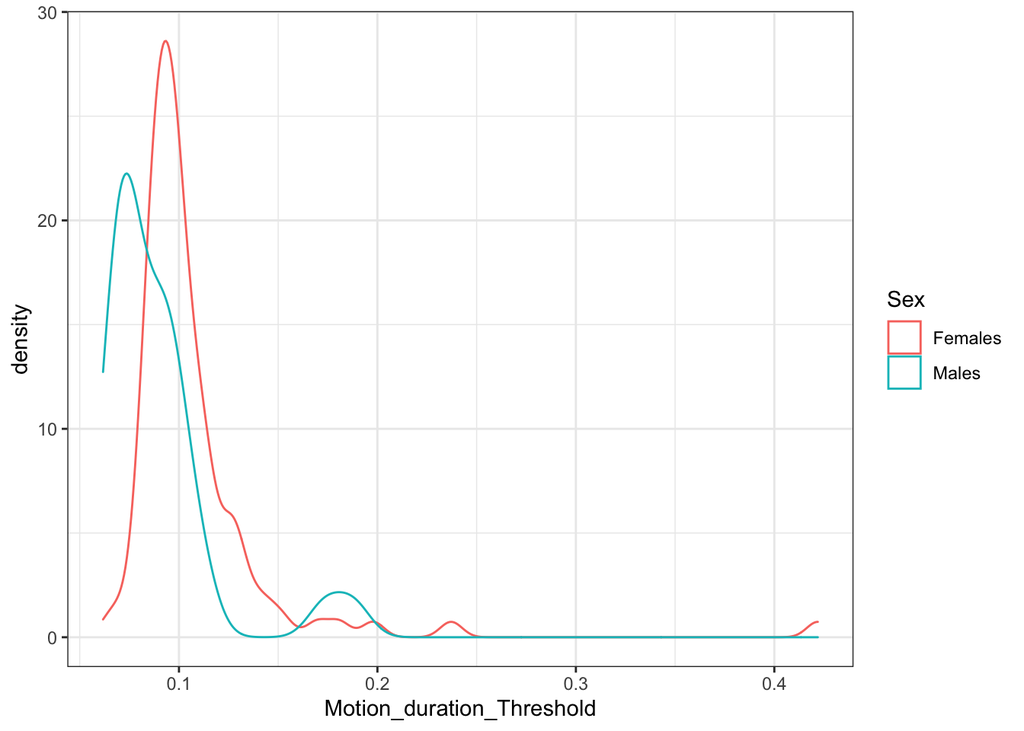

```r
df1 %>% ggplot(aes(x = Motion_duration_Threshold, group = Sex, color = Sex)) +
  geom_density() + theme_bw()
```

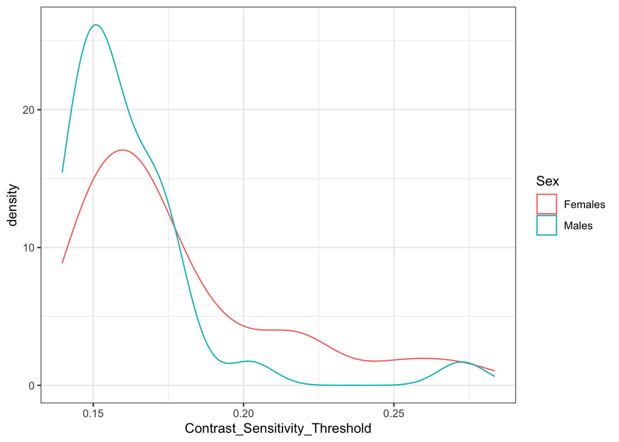

```r
df1 %>% ggplot(aes(x = Contrast_Sensitivity_Threshold, group = Sex, color =
                     Sex)) +
  geom_density() + theme_bw()
```

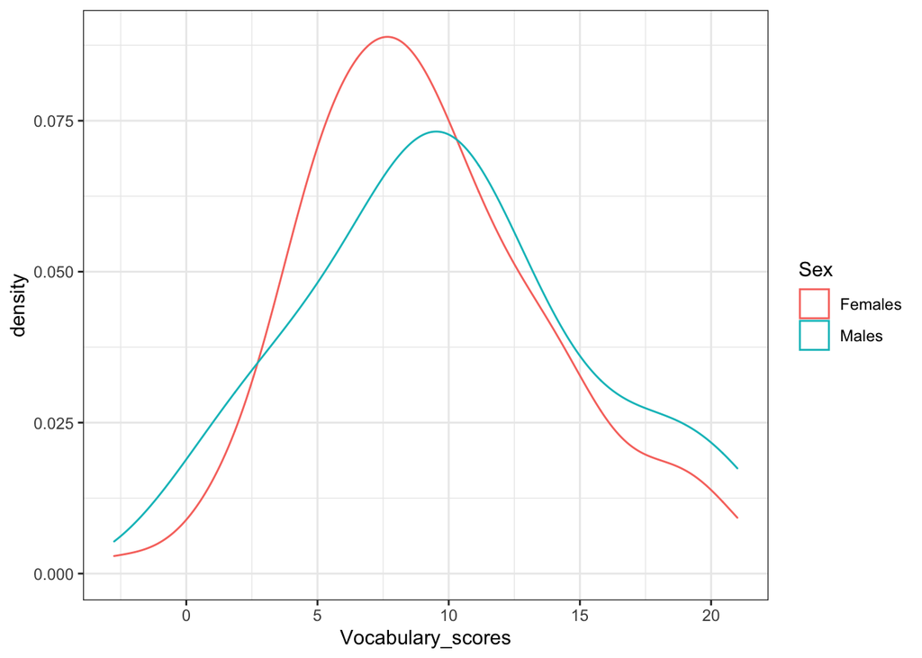

```r
df1 %>% ggplot(aes(x = Vocabulary_scores, group = Sex, color = Sex)) +
  geom_density() + theme_bw()
```

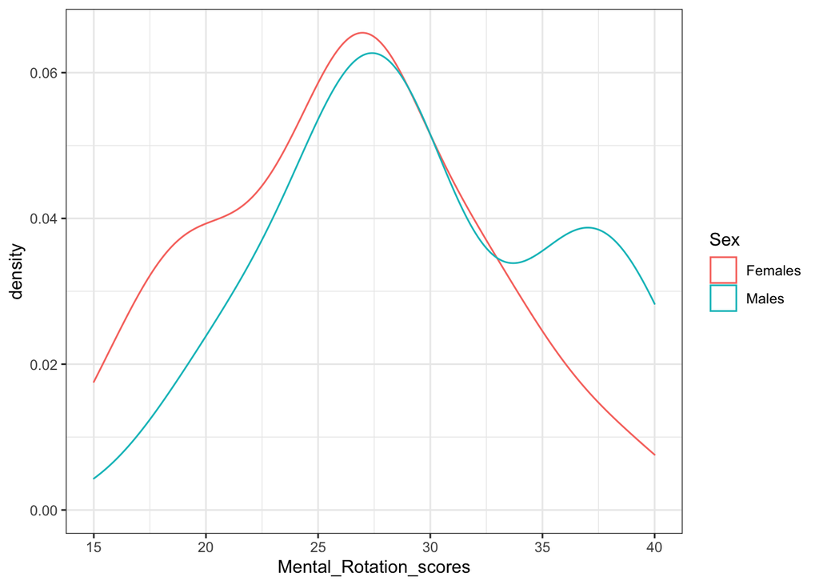

```r
df1 %>% ggplot(aes(x = Mental_Rotation_scores, group = Sex, color = Sex)) +
  geom_density() + theme_bw()
```

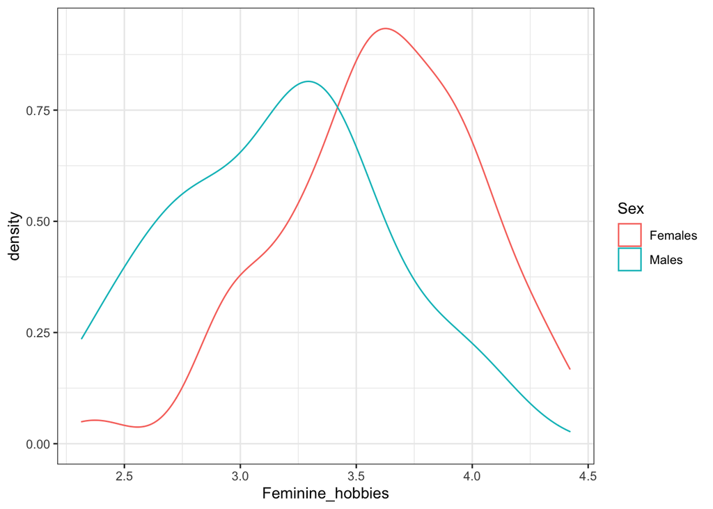

```r
df1 %>% ggplot(aes(x = Feminine_hobbies, group = Sex, color = Sex)) +
  geom_density() + theme_bw()
```

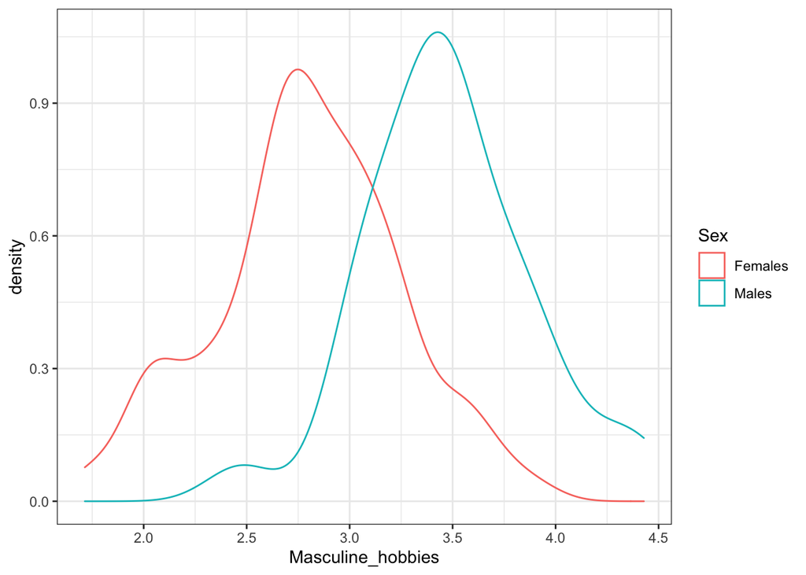

```r
df1 %>% ggplot(aes(x = Masculine_hobbies, group = Sex, color = Sex)) +
  geom_density() + theme_bw()
```

```r
# library(gtsummary)
# table2 <- df1 %>%
#   select("Age","School_year","Major","Handedness","Glasses","Acuity","Color_vision","Stereo","Sex") %>%
#   tbl_summary(
#     by = Sex, # split table by group
#     missing = "no" # don't list missing data separately
#   ) %>%
#   add_n() %>% # add column with total number of non-missing observations
#   add_p() %>% # test for a difference between groups
#   modify_header(label = "**Variable**") %>% # update the column header
#   bold_labels()
```

## Female table

```r
sjPlot::tab_df(psych::describe(df1_f[, 12:19]))
```

| vars | n | mean | sd | median | trimmed | mad | min | max | range | skew | kurtosis | se |
| --- | --- | --- | --- | --- | --- | --- | --- | --- | --- | --- | --- | --- |
| 1 | 98 | 0.11 | 0.04 | 0.10 | 0.10 | 0.01 | 0.06 | 0.42 | 0.36 | 5.14 | 34.13 | 0.00 |
| 2 | 100 | 0.18 | 0.03 | 0.17 | 0.17 | 0.02 | 0.14 | 0.28 | 0.14 | 1.33 | 0.98 | 0.00 |
| 3 | 101 | 9.17 | 4.64 | 8.50 | 8.91 | 4.08 | -2.75 | 21.00 | 23.75 | 0.41 | -0.07 | 0.46 |
| 4 | 101 | 13.91 | 3.92 | 13.00 | 13.78 | 4.45 | 3.00 | 24.00 | 21.00 | 0.21 | -0.02 | 0.39 |
| 5 | 101 | 26.21 | 6.00 | 27.00 | 26.11 | 5.93 | 15.00 | 40.00 | 25.00 | 0.08 | -0.63 | 0.60 |
| 6 | 101 | 8.84 | 4.43 | 9.00 | 8.73 | 4.45 | 1.00 | 20.00 | 19.00 | 0.21 | -0.42 | 0.44 |
| 7 | 101 | 3.60 | 0.42 | 3.63 | 3.62 | 0.39 | 2.32 | 4.42 | 2.11 | -0.43 | 0.05 | 0.04 |
| 8 | 101 | 2.80 | 0.45 | 2.76 | 2.80 | 0.42 | 1.71 | 3.90 | 2.19 | -0.10 | -0.23 | 0.05 |

## Male table

```r
sjPlot::tab_df(psych::describe(df1_m[, 12:19]))
```

| vars | n | mean | sd | median | trimmed | mad | min | max | range | skew | kurtosis | se |
| --- | --- | --- | --- | --- | --- | --- | --- | --- | --- | --- | --- | --- |
| 1 | 30 | 0.09 | 0.03 | 0.08 | 0.08 | 0.02 | 0.06 | 0.19 | 0.13 | 2.16 | 4.61 | 0.01 |
| 2 | 30 | 0.16 | 0.03 | 0.16 | 0.16 | 0.01 | 0.14 | 0.27 | 0.13 | 2.86 | 9.70 | 0.00 |
| 3 | 30 | 9.92 | 5.42 | 9.88 | 9.76 | 5.37 | 0.00 | 21.00 | 21.00 | 0.22 | -0.67 | 0.99 |
| 4 | 30 | 14.47 | 4.46 | 14.00 | 14.54 | 4.45 | 5.00 | 23.00 | 18.00 | -0.10 | -0.69 | 0.81 |
| 5 | 30 | 29.67 | 6.22 | 28.50 | 29.62 | 5.93 | 18.00 | 40.00 | 22.00 | 0.13 | -1.11 | 1.14 |
| 6 | 30 | 11.70 | 5.13 | 11.00 | 11.79 | 5.93 | 1.00 | 20.00 | 19.00 | -0.04 | -0.96 | 0.94 |
| 7 | 30 | 3.16 | 0.46 | 3.21 | 3.16 | 0.47 | 2.32 | 4.11 | 1.79 | 0.06 | -0.79 | 0.08 |
| 8 | 30 | 3.48 | 0.41 | 3.45 | 3.47 | 0.35 | 2.48 | 4.43 | 1.95 | 0.16 | 0.23 | 0.07 |

## t-test: compare between genders

The following is a quotation from our preregistration:

> To examine sex differences, one-tailed t tests will be conducted to compare men and women on 2 visual perception thresholds, spatial ability, and masculine hobbies. We will use verbal ability as our control variable. We set a family-wise Type I error rate at α=0.05. Because there are four dependent variables hypothesized to show sex differences, the critical p value for each sex comparison is 0.0125 after Bonferroni correction. Our goal is to obtain .8 power to detect a medium effect size of .5 (Cohen’s d) at the p value of .0125 in the one-tailed t tests. Unequal sample sizes of the two sexes may be collected in this study. The minimum effect size of .50 can be obtained by at least 45 male participants out of a total sample size of 300 (see the R-code for power analysis at shorturl.at/nDHLV). The minimum detectable effect size decreases when male and female sample sizes differ less, but to simply our t tests, we set the effect sizes at .5.

```r
### Summary Statistic Functions
tb <- df1 %>%
  tab_cells(
    Motion_duration_Threshold,
    Contrast_Sensitivity_Threshold,
    Vocabulary_scores,
    Vocabulary_scores_cor_num,
    Mental_Rotation_scores,
    Mental_Rotation_scores_both,
    Feminine_hobbies,
    Masculine_hobbies
  ) %>%
  tab_cols(total(label = "#Total| |"), Sex) %>%
  tab_stat_fun(
    Mean = w_mean,
    "Std.dev" = w_sd,
    "Valid N" = w_n,
    method = list
  ) %>%
  tab_pivot() #%>%
  #options(digit = 2)
tb
```

|  | #Total Mean | #Total Std.dev | #Total Valid N |  | Sex Females Mean | Sex Females Std.dev | Sex Females Valid N | Sex | Sex Males Mean | Sex Males Std.dev | Sex Males Valid N |
| --- | --- | --- | --- | --- | --- | --- | --- | --- | --- | --- | --- |
| Motion_duration_Threshold | 0.1 | 0.0 | 128 |  | 0.1 | 0.0 | 98 |  | 0.1 | 0.0 | 30 |
| Contrast_Sensitivity_Threshold | 0.2 | 0.0 | 130 |  | 0.2 | 0.0 | 100 |  | 0.2 | 0.0 | 30 |
| Vocabulary_scores | 9.3 | 4.8 | 131 |  | 9.2 | 4.6 | 101 |  | 9.9 | 5.4 | 30 |
| Vocabulary_scores_cor_num | 14.0 | 4.0 | 131 |  | 13.9 | 3.9 | 101 |  | 14.5 | 4.5 | 30 |
| Mental_Rotation_scores | 27.0 | 6.2 | 131 |  | 26.2 | 6.0 | 101 |  | 29.7 | 6.2 | 30 |
| Mental_Rotation_scores_both | 9.5 | 4.7 | 131 |  | 8.8 | 4.4 | 101 |  | 11.7 | 5.1 | 30 |
| Feminine_hobbies | 3.5 | 0.5 | 131 |  | 3.6 | 0.4 | 101 |  | 3.2 | 0.5 | 30 |
| Masculine_hobbies | 3.0 | 0.5 | 131 |  | 2.8 | 0.5 | 101 |  | 3.5 | 0.4 | 30 |

```r
mdt_t <-
  t.test(
    Motion_duration_Threshold ~ Sex,
    data = df1,
    var.equal = F,
    alternative = "greater"
  ) #Hypothesized
mdt_t
```

```
##
##  Welch Two Sample t-test
##
## data:  Motion_duration_Threshold by Sex
## t = 2.7606, df = 69.173, p-value = 0.00369
## alternative hypothesis: true difference in means is greater than 0
## 95 percent confidence interval:
##  0.007252468         Inf
## sample estimates:
## mean in group Females   mean in group Males
##            0.10740195            0.08909149
```

As predicted, we found there are sex differences in motion duration threshold. Males took significantly shorter time to detect the direction of the motion than females.

```r
cst_t <-
  t.test(
    Contrast_Sensitivity_Threshold ~ Sex,
    data = df1,
    var.equal = F,
    alternative = "greater"
  ) #Hypothesized
cst_t
```

```
##
##  Welch Two Sample t-test
##
## data:  Contrast_Sensitivity_Threshold by Sex
## t = 2.7828, df = 65.096, p-value = 0.003523
## alternative hypothesis: true difference in means is greater than 0
## 95 percent confidence interval:
##  0.006407309         Inf
## sample estimates:
## mean in group Females   mean in group Males
##             0.1781956             0.1621926
```

As predicted, we found there are sex differences in contrast sensitivity threshold. Males can detect the stimuli with lower contrast than females.

```r
advoc_total_t <-
  t.test(
    Vocabulary_scores ~ Sex,
    data = df1,
    var.equal = TRUE,
    alternative = "less"
  )
advoc_total_t
```

```
##
##  Two Sample t-test
##
## data:  Vocabulary_scores by Sex
## t = -0.74845, df = 129, p-value = 0.2278
## alternative hypothesis: true difference in means is less than 0
## 95 percent confidence interval:
##       -Inf 0.9111823
## sample estimates:
## mean in group Females   mean in group Males
##              9.165842              9.916667
```

```r
advoc_cor_t <-
  t.test(
    Vocabulary_scores_cor_num ~ Sex,
    data = df1,
    var.equal = TRUE,
    alternative = "less"
  )
advoc_cor_t
```

```
##
##  Two Sample t-test
##
## data:  Vocabulary_scores_cor_num by Sex
## t = -0.66033, df = 129, p-value = 0.2551
## alternative hypothesis: true difference in means is less than 0
## 95 percent confidence interval:
##       -Inf 0.8386487
## sample estimates:
## mean in group Females   mean in group Males
##              13.91089              14.46667
```

Vocabulary is the control variable in the study. As we predicted, the vocabulary score did not differ between males and females.

```r
mrs <-
  t.test(
    Mental_Rotation_scores ~ Sex,
    data = df1,
    var.equal = TRUE,
    alternative = "less"
  ) #Hypothesized
mrs
```

```
##
##  Two Sample t-test
##
## data:  Mental_Rotation_scores by Sex
## t = -2.7478, df = 129, p-value = 0.003429
## alternative hypothesis: true difference in means is less than 0
## 95 percent confidence interval:
##       -Inf -1.373374
## sample estimates:
## mean in group Females   mean in group Males
##              26.20792              29.66667
```

```r
mrs_both <-
  t.test(
    Mental_Rotation_scores_both ~ Sex,
    data = df1,
    var.equal = TRUE,
    alternative = "less"
  )
mrs_both
```

```
##
##  Two Sample t-test
##
## data:  Mental_Rotation_scores_both by Sex
## t = -2.9895, df = 129, p-value = 0.001673
## alternative hypothesis: true difference in means is less than 0
## 95 percent confidence interval:
##       -Inf -1.274324
## sample estimates:
## mean in group Females   mean in group Males
##              8.841584             11.700000
```

```r
#Hypothesized
```

Sex difference in mental rotation test was found in our study. Males have significantly more correct answers in mental rotation task than females. So does in the number of mental rotation items where both correct responses were selected.

```r
femhob <-
  t.test(
    Feminine_hobbies ~ Sex,
    data = df1,
    var.equal = TRUE,
    alternative = "greater"
  )
femhob
```

```
##
##  Two Sample t-test
##
## data:  Feminine_hobbies by Sex
## t = 4.8717, df = 129, p-value = 1.592e-06
## alternative hypothesis: true difference in means is greater than 0
## 95 percent confidence interval:
##  0.2887051       Inf
## sample estimates:
## mean in group Females   mean in group Males
##              3.602397              3.164912
```

Although we did not hypothesized female-type hobbies in preregistration, we found females had higher scores in female-typed hobbies than males.

```r
mashob <-
  t.test(
    Masculine_hobbies ~ Sex,
    data = df1,
    var.equal = TRUE,
    alternative = "less"
  ) #Hypothesized
mashob
```

```
##
##  Two Sample t-test
##
## data:  Masculine_hobbies by Sex
## t = -7.422, df = 129, p-value = 6.896e-12
## alternative hypothesis: true difference in means is less than 0
## 95 percent confidence interval:
##        -Inf -0.5307975
## sample estimates:
## mean in group Females   mean in group Males
##              2.797619              3.480952
```

As predicted, we found males have higher scores in male-typed hobbies than females.

```r
P_value <-
  c(
    mdt_t$p.value,
    cst_t$p.value,
    advoc_total_t$p.value,
    advoc_cor_t$p.value,
    mrs$p.value,
    mrs_both$p.value,
    femhob$p.value,
    mashob$p.value
  )
tb2 <- cbind(tb, P_value)
tb2
```

```
##                       row_labels #Total| |Mean #Total| |Std.dev
## 1      Motion_duration_Threshold     0.1031104       0.03903413
## 2 Contrast_Sensitivity_Threshold     0.1745026       0.03326781
## 3              Vocabulary_scores     9.3377863       4.81643058
## 4      Vocabulary_scores_cor_num    14.0381679       4.03904897
## 5         Mental_Rotation_scores    27.0000000       6.20421693
## 6    Mental_Rotation_scores_both     9.4961832       4.73672078
## 7               Feminine_hobbies     3.5022097       0.46813026
## 8              Masculine_hobbies     2.9541076       0.52691206
##   #Total| |Valid N Sex|Females|Mean Sex|Females|Std.dev Sex|Females|Valid N
## 1              128        0.1074019          0.04091639                  98
## 2              130        0.1781956          0.03459756                 100
## 3              131        9.1658416          4.63617262                 101
## 4              131       13.9108911          3.91943621                 101
## 5              131       26.2079208          6.00386014                 101
## 6              131        8.8415842          4.43110071                 101
## 7              131        3.6023971          0.42357633                 101
## 8              131        2.7976190          0.45273795                 101
##   Sex|Males|Mean Sex|Males|Std.dev Sex|Males|Valid N      P_value
## 1     0.08909149        0.02841308                30 3.690012e-03
## 2     0.16219257        0.02516039                30 3.522855e-03
## 3     9.91666667        5.42437559                30 2.277754e-01
## 4    14.46666667        4.46235853                30 2.551093e-01
## 5    29.66666667        6.22194854                30 3.429178e-03
## 6    11.70000000        5.13372890                30 1.673419e-03
## 7     3.16491228        0.45940014                30 1.592022e-06
## 8     3.48095238        0.40663625                30 6.896227e-12
```

## power analysis

```r
t_power <-
  pwr.t2n.test(
    n1 = 102 ,
    n2 = 30 ,
    d = NULL,
    sig.level = 0.0125,
    power = 0.8,
    alternative = "greater"
  )
t_power
```

```
##
##      t test power calculation
##
##              n1 = 102
##              n2 = 30
##               d = 0.6465883
##       sig.level = 0.0125
##           power = 0.8
##     alternative = greater
```

We need |d|>0.65 for one-side t test with p value of lower than 0.0125 with the power of 0.8.

## correlation within sex

The following is a quotation from our preregistered analysis plan:

> To examine how individual differences of visual perception measures are associated with other tasks, we will use correlations within sex. The lower visual perception threshold is, the higher perceptual sensitivity this individual has. In both sexes, we expect to find negative correlations between visual perception measures and spatial ability and masculine hobbies, but no significant correlation with verbal ability. There are four planned correlations (two visual perception tasks × two cognitive tasks) within sex, for a total of eight. This project is a novel study that has not to our knowledge been conducted previously. So we have consciously decided to maintain strict control of Type II error, in order to have enough statistical power to detect a small correlation effect sizes (r=0.20) within the constraints of sample size. This decision to maximize the power (.80) leads to a trade-off between Type I and Type II error. We plan to conduct eight separate one-tailed correlation tests with Type I error at 0.05 and no Bonferroni correction. With a critical p value of .05, around 150 participants are required for each group to detect an effect size of 0.20 at an obtained power of 0.8 with a one-tailed correlation test.

### Females

```r
# correlation table
# round(cor(df1_f[,3:9], use = "complete.obs",  method = "spearman"),
#   digits = 2 # rounded to 2 decimals
# )

# library(Hmisc)
# res <- rcorr(as.matrix(df1_f[,3:10], type = c("pearson")))  # could I do one-side? "spearman"
# # Extract the correlation coefficients
# round(res$r, 2)
# # Extract p-values
# round(res$P, 3)

sjp.corr(
  df1_f[, 12:19],
  na.deletion = c("pairwise"),
  corr.method = c("pearson"),
  title = "Correlation Table in female participants",
  decimals = 2
#  triangle = "lower",
#  file = NULL
)
```

```
## Computing correlation using pearson-method with pairwise-deletion...
```

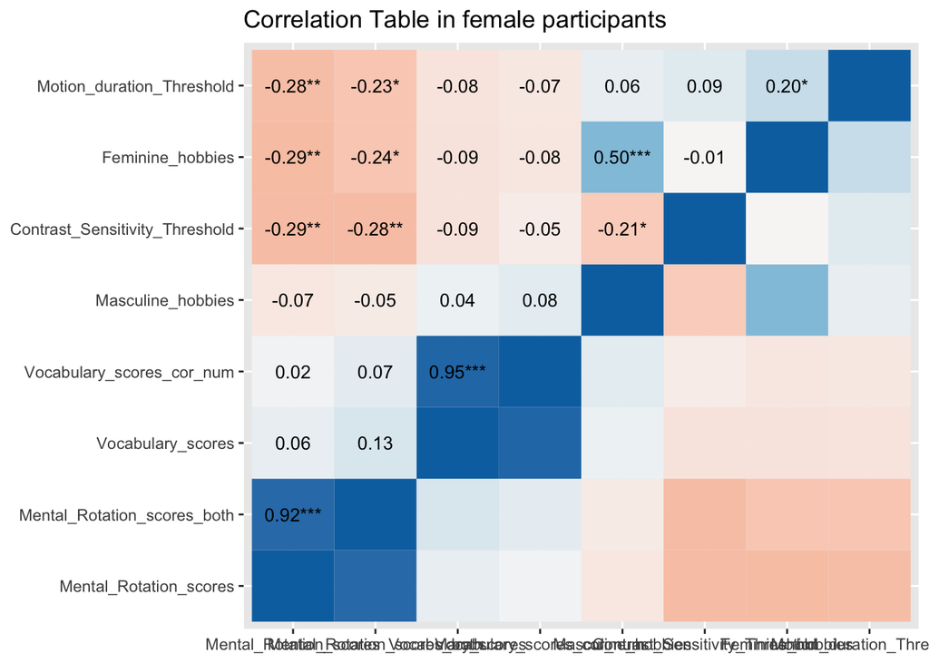

### Males

```r
# correlation table
# round(cor(df1_f[,3:9], use = "complete.obs",  method = "spearman"),
#   digits = 2 # rounded to 2 decimals
# )

# res_m <- rcorr(as.matrix(df1_m[,3:10], type = c("spearson")))  # could I do one-side? "spearman"
# # Extract the correlation coefficients
# round(res_m$r, 2)
# # Extract p-values
# round(res_m$P, 3)

sjp.corr(
  df1_m[, 12:19],
  na.deletion = c("pairwise"),
  corr.method = c("pearson"),
  title = "Correlation Table in male participants",
  decimals = 2
  #triangle = "lower",
  #file = NULL
)
```

```
## Computing correlation using pearson-method with pairwise-deletion...
```

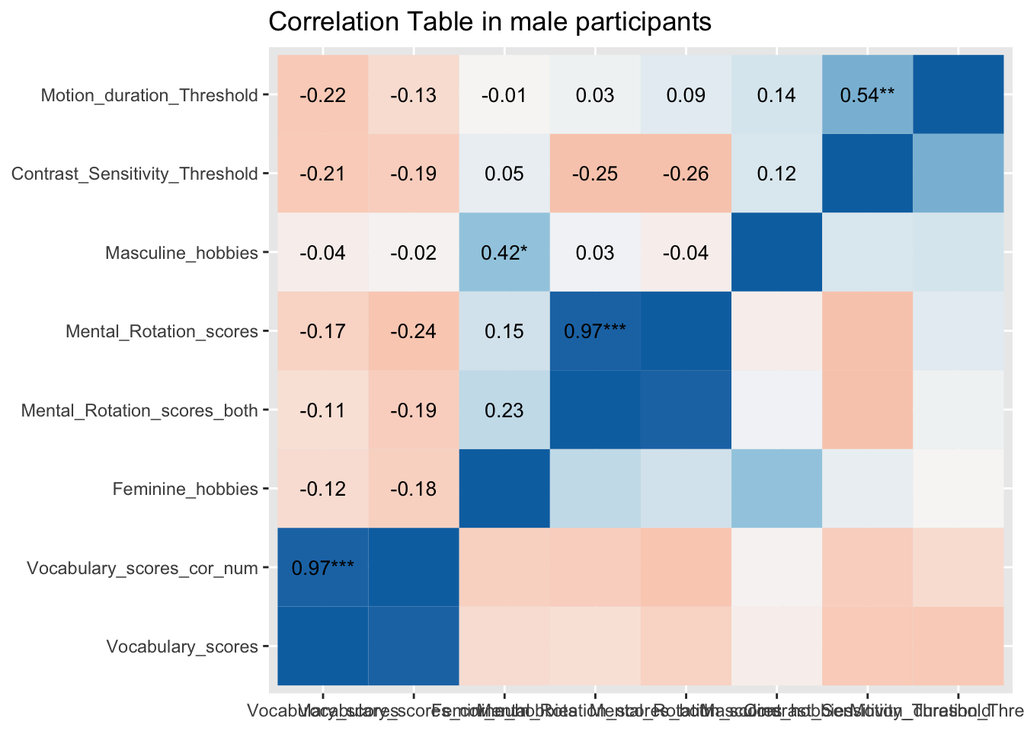

- We found that motion duration thresholds are positively correlated with contrast sensitivity threshold in males ($p< 0.01$).

## Visualization

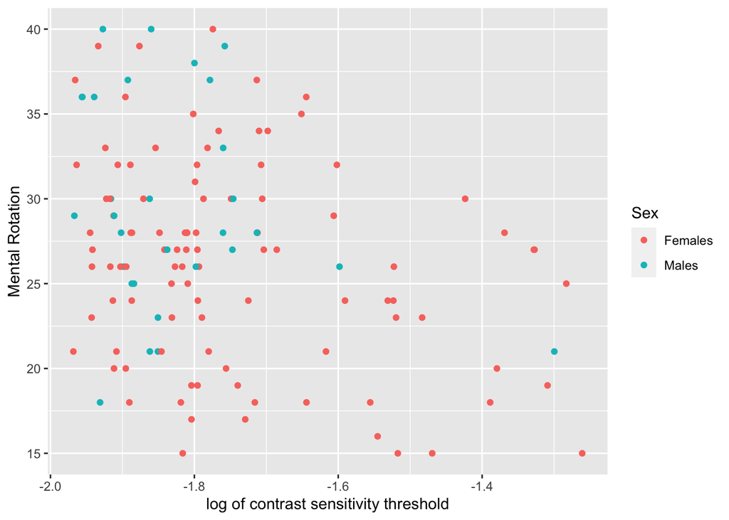

```r
df1 %>% ggplot(aes(
  x = log(Contrast_Sensitivity_Threshold),
  y = Mental_Rotation_scores,
  group = Sex,
  color = Sex
)) +
  geom_point() + xlab("log of contrast sensitivity threshold") + ylab("Mental Rotation")
```

```r
stat_smooth(method = "lm", na.rm = TRUE)
```

```
## geom_smooth: se = TRUE, na.rm = TRUE, orientation = NA
## stat_smooth: method = lm, formula = NULL, se = TRUE, n = 80, fullrange = FALSE, level = 0.95, na.rm = TRUE, orientation = NA, method.args = list(), span = 0.75
## position_identity
```

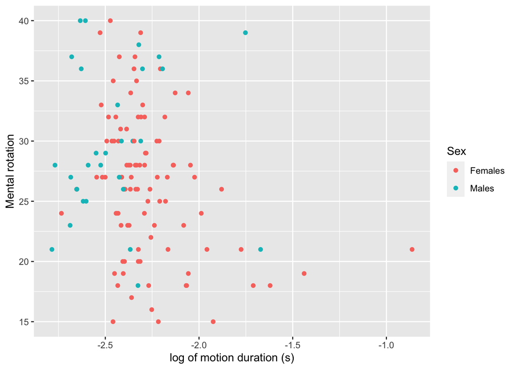

```r
df1 %>% ggplot(aes(
  x = log(Motion_duration_Threshold),
  y = Mental_Rotation_scores,
  group = Sex,
  color = Sex
)) +
  geom_point() + xlab("log of motion duration (s)") + ylab("Mental rotation")
```

```r
stat_smooth(method = "lm", na.rm = TRUE)
```

```
## geom_smooth: se = TRUE, na.rm = TRUE, orientation = NA
## stat_smooth: method = lm, formula = NULL, se = TRUE, n = 80, fullrange = FALSE, level = 0.95, na.rm = TRUE, orientation = NA, method.args = list(), span = 0.75
## position_identity
```

```r
save_plot(
  "cor-plot2.tif",
  fig = last_plot(),
  width = 12,
  height = 9,
  dpi = 600
)
```

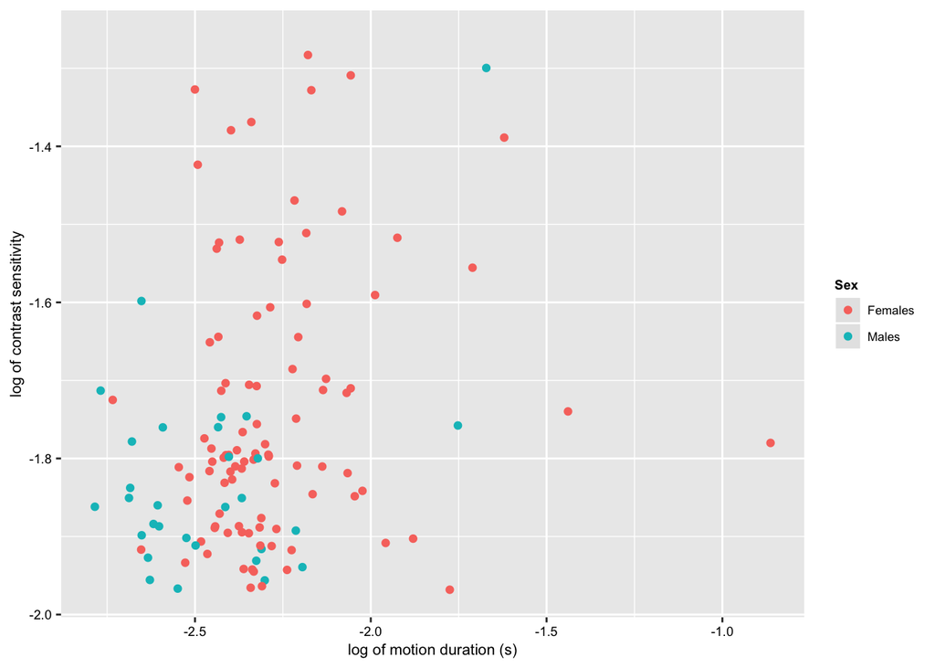

```r
df1 %>% ggplot(aes(
  x = log(Motion_duration_Threshold),
  y = log(Contrast_Sensitivity_Threshold),
  group = Sex,
  color = Sex
)) +
  geom_point() + xlab("log of motion duration (s)") + ylab("log of contrast sensitivity")
```

```r
stat_smooth(method = "lm", na.rm = TRUE)
```

```
## geom_smooth: se = TRUE, na.rm = TRUE, orientation = NA
## stat_smooth: method = lm, formula = NULL, se = TRUE, n = 80, fullrange = FALSE, level = 0.95, na.rm = TRUE, orientation = NA, method.args = list(), span = 0.75
## position_identity
```

Scatterplot of contrast sensitivity threshold and mental rotation scores in famales

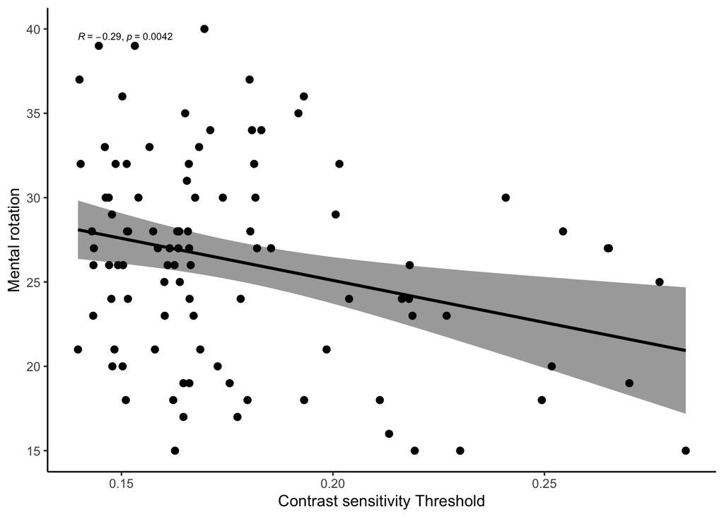

```r
ggscatter(
  df1_f,
  x = "Contrast_Sensitivity_Threshold",
  y = "Mental_Rotation_scores",
  add = "reg.line",
  conf.int = TRUE,
  cor.coef = TRUE,
  cor.method = "pearson",
  xlab = "Contrast sensitivity Threshold",
  ylab = "Mental rotation"
) + theme_classic()
```

Scatterplot of motion duration threshold and mental rotation scores in famales

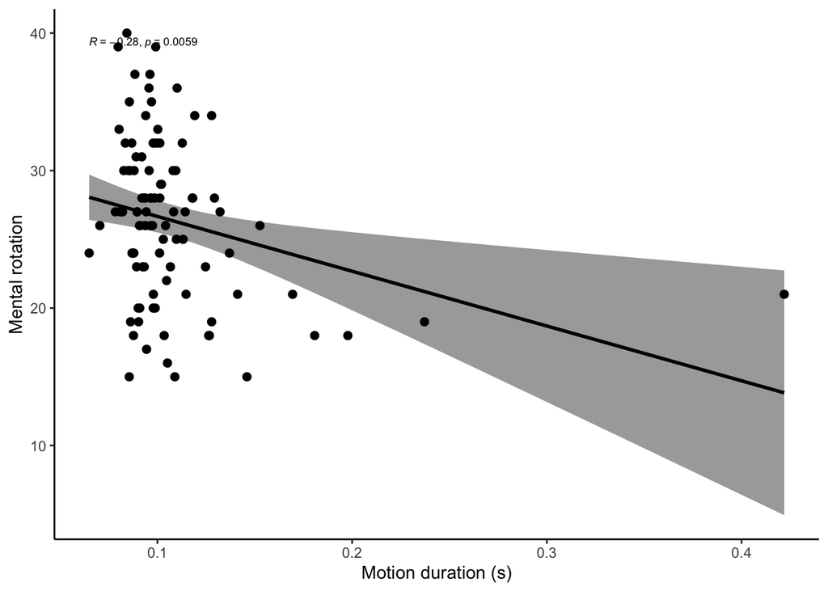

```r
ggscatter(
  df1_f,
  x = "Motion_duration_Threshold",
  y = "Mental_Rotation_scores",
  add = "reg.line",
  conf.int = TRUE,
  cor.coef = TRUE,
  cor.method = "pearson",
  xlab = "Motion duration (s)",
  ylab = "Mental rotation"
) + theme_classic()
```

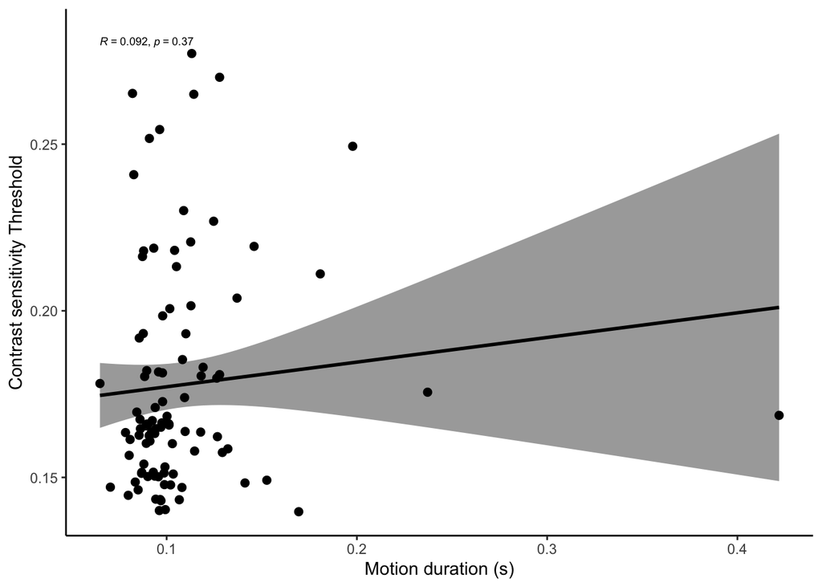

```r
ggscatter(
  df1_f,
  x = "Motion_duration_Threshold",
  y = "Contrast_Sensitivity_Threshold",
  add = "reg.line",
  conf.int = TRUE,
  cor.coef = TRUE,
  cor.method = "pearson",
  xlab = "Motion duration (s)",
  ylab = "Contrast sensitivity Threshold"
) + theme_classic()
```

Power analysis

```r
# MRT_cor and mdt

r_powerf <-
  pwr.r.test(
    n = 102,
    r = NULL,
    sig.level = 0.05,
    power = 0.8,
    alternative = "greater"
  )
r_powerf
```

```
##
##      approximate correlation power calculation (arctangh transformation)
##
##               n = 102
##               r = 0.2436479
##       sig.level = 0.05
##           power = 0.8
##     alternative = greater
```

```r
r_powerm <-
  pwr.r.test(
    n = 30,
    r = NULL,
    sig.level = 0.05,
    power = 0.8,
    alternative = "greater"
  )
r_powerm
```

```
##
##      approximate correlation power calculation (arctangh transformation)
##
##               n = 30
##               r = 0.4386874
##       sig.level = 0.05
##           power = 0.8
##     alternative = greater
```

As for sample size of 102, we need |r|>0.24 for one-side t test with p value of lower than 0.05 with the power of 0.8. As for sample size of 30, we need |r|>0.44 for one-side t test with p value of lower than 0.05 with the power of 0.8.

# Publication

- Nature Scientific Report https://www.nature.com/srep/author-instructions/submission-guidelines
  - Word limit: no more than 4,500 words (not including Abstract, Methods, References and figure legends)
  - Aim & Scopes: Biological sciences/Health sciences?
  - IF: 3.998
- Nature Human behavior https://www.nature.com/nathumbehav/about/content
  - The main text (excluding the Abstract, Methods, References and Tables/Figure Captions) is 3,000—5,000 words.
  - including (but not limited to) perception, action, memory, learning, reward, judgment, decision-making, language, communication, emotion, personality, social cognition, social behaviour, neuropsychiatric/neurodevelopmental/neurological disorders, economic & political behaviour, belief systems, social networks, social norms, social structures, behaviour change, collective cognition and behaviour, culture, public policy.
  - Preregistered report: Wanted
  - IF: 12.282
- Current biology https://www.cell.com/current-biology/article-types
  - Word limit: Articles (~5000 words)/Reports (~2500 words)?
  - Aim & Scopes: findings in any area of biology that have sufficient claim to be of general interest
  - IF: 9.601